# Chapter 7 - Gene Expression Analysis - Microarrays

Sasha Ajay Malkani

2025-12-29

## 1. Gene Expression Analysis - Microarrays

Gene expression analysis is a cornerstone of bioinformatics and molecular biology, providing insights into cellular functions, regulations, and underlying mechanisms of diseases. With the advancement of genomic technologies, microarrays have emerged as a powerful technique for measuring the expression levels of thousands of genes simultaneously. This chapter aims to guide readers through the process of analyzing microarray data using R, a widely-used programming language in bioinformatics, emphasizing the tools and techniques that facilitate gene expression analysis.

### 1. A. Overview of Microarrays

Microarrays are a high-throughput technology that allows researchers to analyze gene expression profiles across various conditions or treatments. Each microarray consists of thousands of DNA probes, each corresponding to a specific gene. The basic principle involves hybridizing labelled RNA or cDNA samples to the probes, where the fluorescent signal intensity at each spot indicates the level of gene expression.

#### 1. A. I. Types of Microarrays

- **cDNA Microarrays**: Composed of known cDNAs and used for comparative analysis of gene expression.
- **Oligonucleotide Microarrays**: Contain short, synthetic oligonucleotides that provide high specificity and sensitivity for gene expression profiling.
- **SNP Arrays**: Used to detect single nucleotide polymorphisms rather than gene expression.

### 1. B. Data Acquisition and Pre-processing.

Before diving into analysis, the first step is acquiring the raw microarray data. This may involve downloading data from repositories such as the **Gene Expression Omnibus (GEO)** or **The European Nucleotide Archive (ENA)**. Once data is obtained, pre-processing is crucial.

#### 1. B. I. Loading Data into R

R provides several packages to facilitate the import and management of microarray data. Below is a code snippet demonstrating how to load data from GEO data set using the “GEOquery” package.

```r
# Install and load necessary packages
# install.packages("BiocManager")
# BiocManager::install("GEOquery")
library(GEOquery)
library(Biobase)

# Load GEO dataset
geo_dataset <- getGEO("GSE57820", GSEMatrix = TRUE)
```

```
## Found 1 file(s)
```

```
## GSE57820_series_matrix.txt.gz
```

```r
ls()
```

```
## [1] "geo_dataset"
```

```r
# Re-assign dataset name to something shorter
geo = geo_dataset
geo
```

```
## $GSE57820_series_matrix.txt.gz
## ExpressionSet (storageMode: lockedEnvironment)
## assayData: 47323 features, 12 samples
##   element names: exprs
## protocolData: none
## phenoData
##   sampleNames: GSM1394594 GSM1394595 ... GSM1394605 (12 total)
##   varLabels: title geo_accession ... transfected with:ch1 (45 total)
##   varMetadata: labelDescription
## featureData
##   featureNames: ILMN_1343291 ILMN_1343295 ... ILMN_3311190 (47323
##     total)
##   fvarLabels: ID Species ... GB_ACC (30 total)
##   fvarMetadata: Column Description labelDescription
## experimentData: use 'experimentData(object)'
##   pubMedIds: 25907805
## Annotation: GPL10558
```

```r
# Title of study
geo[["GSE57820_series_matrix.txt.gz"]]@experimentData@title
```

```
## [1] "The effect of miRNA-135b overexpression on the gene expression profile of LNCaP cells"
```

```r
# Abstract
geo[["GSE57820_series_matrix.txt.gz"]]@experimentData@abstract
```

[output not shown]

```r
# Split geo_dataset into pdata, fdata and expression data
ls()
```

```
## [1] "geo"         "geo_dataset"
```

```r
geo = geo_dataset
geo
```

```
## $GSE57820_series_matrix.txt.gz
## ExpressionSet (storageMode: lockedEnvironment)
## assayData: 47323 features, 12 samples
##   element names: exprs
## protocolData: none
## phenoData
##   sampleNames: GSM1394594 GSM1394595 ... GSM1394605 (12 total)
##   varLabels: title geo_accession ... transfected with:ch1 (45 total)
##   varMetadata: labelDescription
## featureData
##   featureNames: ILMN_1343291 ILMN_1343295 ... ILMN_3311190 (47323
##     total)
##   fvarLabels: ID Species ... GB_ACC (30 total)
##   fvarMetadata: Column Description labelDescription
## experimentData: use 'experimentData(object)'
##   pubMedIds: 25907805
## Annotation: GPL10558
```

```r
pdata_geo=geo[["GSE57820_series_matrix.txt.gz"]]@phenoData
pdata_geo <- pData(pdata_geo)
head(pdata_geo, n =2)
```

```
##                            title geo_accession                status
## GSM1394594 LNCaP_miR-135b_12h_B1    GSM1394594 Public on Apr 21 2015
## GSM1394595 LNCaP_miR-135b_12h_B2    GSM1394595 Public on Apr 21 2015
##            submission_date last_update_date type channel_count
## GSM1394594     May 20 2014      Apr 21 2015  RNA             1
## GSM1394595     May 20 2014      Apr 21 2015  RNA             1
##               source_name_ch1 organism_ch1 characteristics_ch1
## GSM1394594 LNCaP_miR-135b_12h Homo sapiens    cell line: LNCaP
## GSM1394595 LNCaP_miR-135b_12h Homo sapiens    cell line: LNCaP
##            characteristics_ch1.1         characteristics_ch1.2
## GSM1394594 dsmz  cat. #: ACC 256 cell type: Prostate carcinoma
## GSM1394595 dsmz  cat. #: ACC 256 cell type: Prostate carcinoma
##                                                                                                          characteristics_ch1.3
## GSM1394594 cell line origin: Left supraclavicular lymph node metastasis from a 50-year-old man with prostate carcinoma in 1977
## GSM1394595 cell line origin: Left supraclavicular lymph node metastasis from a 50-year-old man with prostate carcinoma in 1977
##                                                                              characteristics_ch1.4
## GSM1394594 cell morphology: Adherent fibroblastoid cells growing in aggregates and as single cells
## GSM1394595 cell morphology: Adherent fibroblastoid cells growing in aggregates and as single cells
##                                                        characteristics_ch1.5
## GSM1394594 transfected with: Ambion pre-miR™ construct for miR-135b at 20 nM
## GSM1394595 transfected with: Ambion pre-miR™ construct for miR-135b at 20 nM
##            characteristics_ch1.6            biomaterial_provider_ch1
## GSM1394594  incubation time: 12h DSMZ (http://www.dsmz.de/home.html)
## GSM1394595  incubation time: 12h DSMZ (http://www.dsmz.de/home.html)
##                                                                                                                                                                  treatment_protocol_ch1
## GSM1394594 LNCaP cells were transfected with Ambion pre-miR™ construct for miR-135b or with pre-miR negative control #1 (scrambled pre-miR) at 20 nM, and incubated for 12h, 24h or 36h
## GSM1394595 LNCaP cells were transfected with Ambion pre-miR™ construct for miR-135b or with pre-miR negative control #1 (scrambled pre-miR) at 20 nM, and incubated for 12h, 24h or 36h
##                                                        growth_protocol_ch1
## GSM1394594 Normal growth conditions, according to instructions by provider
## GSM1394595 Normal growth conditions, according to instructions by provider
##            molecule_ch1
## GSM1394594    total RNA
## GSM1394595    total RNA
##                                                                            extract_protocol_ch1
## GSM1394594 The total cellular RNAs were isolated with MiRVana total RNA isolation kit (Ambion).
## GSM1394595 The total cellular RNAs were isolated with MiRVana total RNA isolation kit (Ambion).
##            label_ch1
## GSM1394594    biotin
## GSM1394595    biotin
##                                                                                                                                                                                                                                                                            label_protocol_ch1
```

[output cut: 29 more lines]

```
##                                                                                         cell line origin:ch1
## GSM1394594 Left supraclavicular lymph node metastasis from a 50-year-old man with prostate carcinoma in 1977
## GSM1394595 Left supraclavicular lymph node metastasis from a 50-year-old man with prostate carcinoma in 1977
##            cell line:ch1
## GSM1394594         LNCaP
## GSM1394595         LNCaP
##                                                               cell morphology:ch1
## GSM1394594 Adherent fibroblastoid cells growing in aggregates and as single cells
## GSM1394595 Adherent fibroblastoid cells growing in aggregates and as single cells
##                 cell type:ch1 dsmz  cat. #:ch1 incubation time:ch1
## GSM1394594 Prostate carcinoma          ACC 256                 12h
## GSM1394595 Prostate carcinoma          ACC 256                 12h
##                                       transfected with:ch1
## GSM1394594 Ambion pre-miR™ construct for miR-135b at 20 nM
## GSM1394595 Ambion pre-miR™ construct for miR-135b at 20 nM
```

```r
fdata_geo = geo[["GSE57820_series_matrix.txt.gz"]]@featureData
head(fdata_geo)
```

```
## An object of class 'AnnotatedDataFrame'
##   featureNames: ILMN_1343291 ILMN_1343295 ... ILMN_1651221 (6 total)
##   varLabels: ID Species ... GB_ACC (30 total)
##   varMetadata: Column Description labelDescription
```

```r
expression_data = geo[["GSE57820_series_matrix.txt.gz"]]@assayData[["exprs"]]
head(expression_data, n = 5)
```

```
##              GSM1394594 GSM1394595 GSM1394596 GSM1394597 GSM1394598 GSM1394599
## ILMN_1343291  14.891974  14.849572  14.834550  14.910567  14.910567  14.801270
## ILMN_1343295  13.761025  13.706857  13.954963  13.924644  13.579431  13.924644
## ILMN_1651199   6.275961   6.343446   6.283629   6.124849   6.412476   6.505916
## ILMN_1651209   6.693395   6.793032   6.592576   6.892616   6.829350   6.768789
## ILMN_1651210   6.581390   6.639940   6.667431   6.754687   6.628422   6.517630
##              GSM1394600 GSM1394601 GSM1394602 GSM1394603 GSM1394604 GSM1394605
## ILMN_1343291  14.924327  14.849572  14.931927  14.895994  14.834550  14.852505
## ILMN_1343295  13.816579  13.405963  13.832293  13.575681  13.646512  13.677568
## ILMN_1651199   6.417343   6.291866   6.527864   6.287655   6.188871   6.462673
## ILMN_1651209   6.670192   6.687871   6.641556   6.747108   6.818057   6.854169
## ILMN_1651210   6.684886   6.491954   6.501823   6.738004   6.633556   6.450855
```

#### 1. B. II. Quality Control

Quality control is essential to ensure that the data is reliable and suitable for analysis. This step involves identifying and removing low-quality samples or outliers. Common tools for visualizaing data quality include box plots, density plots and principal component analysis (PCA).

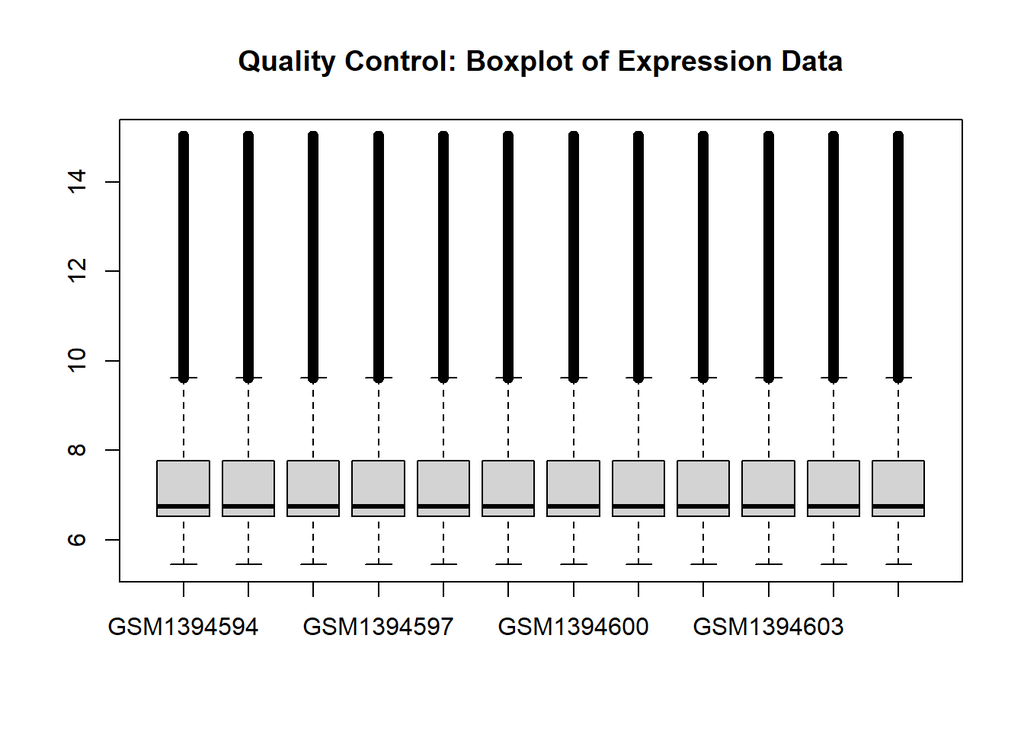

```r
# Boxplot
boxplot(expression_data, main = "Quality Control: Boxplot of Expression Data")
```

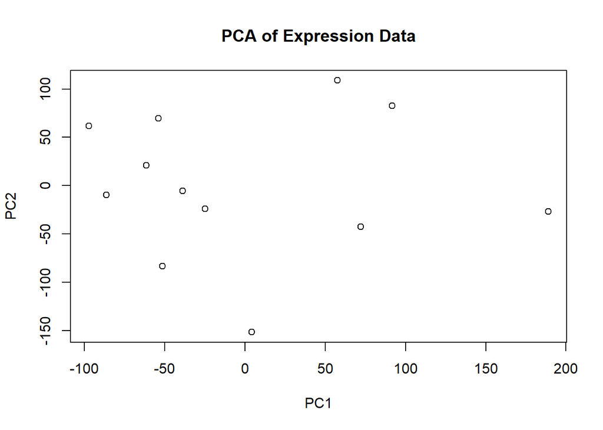

```r
# PCA for outlier detection
pca_result <- prcomp(t(expression_data), scale. = TRUE)
plot(pca_result$x, main = "PCA of Expression Data")
```

#### 1. B. III. Normalization

Normalization adjusts the data to account for systematic biases and ensures that differences in expression levels are biological rather than technical artifacts. Several methods exist, with the “RMA” (Robust Multi-array Average) algorithm being a commonly used approach for background correction, normalization, and summarization.

```r
# Normalizing data using RMA method
# BiocManager::install("affy")
library(affy)
# normalized_data <- rma(geo_dataset[[1]])

# Error: unable to find an inherited method for function ‘probeNames’ for signature
# ‘object = "ExpressionSet"’

# The error you are seeing:
```

Error: unable to find an inherited method for function ‘probeNames’ for signature ‘object = “ExpressionSet”’ indicates that the rma function is expecting an input of a different class (usually AffyBatch), but you are providing an object of class ExpressionSet. The rma function from the affy package does not directly operate on an ExpressionSet; it expects raw CEL files read using ReadAffy() or similar functions.

Here’s a structured way to solve this:

#### Download Raw CEL Files (preferred for rma)

Example GEO accession geo_id <- “GSE57820”

#### Download the GEO dataset including raw CEL files

geo_data <- getGEO(geo_id, GSEMatrix = FALSE)

#### Check if raw CEL files exist:

names(geo_data) # Should include CEL files under supplementary files

#### Normalize using RMA

normalized_data <- rma(affy_data)

#### If You Only Have ExpressionSet

If you only have an ExpressionSet already, RMA has likely already been applied to the data. Use exprs() to access normalized expression values:

```r
# Access expression matrix
normalized_data <- exprs(geo_dataset[[1]])
head(normalized_data)
```

```
##              GSM1394594 GSM1394595 GSM1394596 GSM1394597 GSM1394598 GSM1394599
## ILMN_1343291  14.891974  14.849572  14.834550  14.910567  14.910567  14.801270
## ILMN_1343295  13.761025  13.706857  13.954963  13.924644  13.579431  13.924644
## ILMN_1651199   6.275961   6.343446   6.283629   6.124849   6.412476   6.505916
## ILMN_1651209   6.693395   6.793032   6.592576   6.892616   6.829350   6.768789
## ILMN_1651210   6.581390   6.639940   6.667431   6.754687   6.628422   6.517630
## ILMN_1651221   6.484436   6.557183   6.679497   6.544760   6.807002   6.644649
##              GSM1394600 GSM1394601 GSM1394602 GSM1394603 GSM1394604 GSM1394605
## ILMN_1343291  14.924327  14.849572  14.931927  14.895994  14.834550  14.852505
## ILMN_1343295  13.816579  13.405963  13.832293  13.575681  13.646512  13.677568
## ILMN_1651199   6.417343   6.291866   6.527864   6.287655   6.188871   6.462673
## ILMN_1651209   6.670192   6.687871   6.641556   6.747108   6.818057   6.854169
## ILMN_1651210   6.684886   6.491954   6.501823   6.738004   6.633556   6.450855
## ILMN_1651221   6.751655   6.800670   6.619949   6.704500   6.662003   6.535387
```

Applying rma() again is not necessary and will error out because ExpressionSet is not compatible with rma.

### 1. C. Differential Expression Analysis

Once the data is pre-processed and normalized, the focus shifts to identifying differentially expressed genes (DEGs) across experimental conditions. The “limma” package is a popular choice for this purpose, utilizing linear modelling and empirical Bayes methods

#### 1. C. I. Design Matrix

Before performing differential expression analysis, define the experimental design with a design matrix that captures the conditions being compared.

#### Create a design matrix

- **treatment samples**

GSM1394594 GSM1394595 GSM1394596 GSM1394597 GSM1394598 GSM1394599

- **negative control samples**

GSM1394600 GSM1394601 GSM1394602 GSM1394603 GSM1394604 GSM1394605

```r
# Sample data setup (replace with your actual data)
sample_names <- paste0("Sample", 1:12)
sample_names
```

```
##  [1] "Sample1"  "Sample2"  "Sample3"  "Sample4"  "Sample5"  "Sample6"
##  [7] "Sample7"  "Sample8"  "Sample9"  "Sample10" "Sample11" "Sample12"
```

```r
sample_ids <- geo[["GSE57820_series_matrix.txt.gz"]]@phenoData@data[["geo_accession"]]
sample_ids
```

```
##  [1] "GSM1394594" "GSM1394595" "GSM1394596" "GSM1394597" "GSM1394598"
##  [6] "GSM1394599" "GSM1394600" "GSM1394601" "GSM1394602" "GSM1394603"
## [11] "GSM1394604" "GSM1394605"
```

```r
titles <- geo[["GSE57820_series_matrix.txt.gz"]]@phenoData@data[["title"]]
titles
```

```
##  [1] "LNCaP_miR-135b_12h_B1" "LNCaP_miR-135b_12h_B2" "LNCaP_miR-135b_24h_B1"
##  [4] "LNCaP_miR-135b_24h_B2" "LNCaP_miR-135b_36h_B1" "LNCaP_miR-135b_36h_B2"
##  [7] "LNCaP_Scr_12h_B1"      "LNCaP_Scr_12h_B2"      "LNCaP_Scr_24h_B1"
## [10] "LNCaP_Scr_24h_B2"      "LNCaP_Scr_36h_B1"      "LNCaP_Scr_36h_B2"
```

```r
groups <- factor(rep(c("Treatment", "Control"), each = 6))
groups
```

```
##  [1] Treatment Treatment Treatment Treatment Treatment Treatment Control
##  [8] Control   Control   Control   Control   Control
## Levels: Control Treatment
```

```r
pheno_data <- data.frame(SampleName = sample_names, Sample_id = sample_ids, Title = titles, Group = groups)
pheno_data
```

```
##    SampleName  Sample_id                 Title     Group
## 1     Sample1 GSM1394594 LNCaP_miR-135b_12h_B1 Treatment
## 2     Sample2 GSM1394595 LNCaP_miR-135b_12h_B2 Treatment
## 3     Sample3 GSM1394596 LNCaP_miR-135b_24h_B1 Treatment
## 4     Sample4 GSM1394597 LNCaP_miR-135b_24h_B2 Treatment
## 5     Sample5 GSM1394598 LNCaP_miR-135b_36h_B1 Treatment
## 6     Sample6 GSM1394599 LNCaP_miR-135b_36h_B2 Treatment
## 7     Sample7 GSM1394600      LNCaP_Scr_12h_B1   Control
## 8     Sample8 GSM1394601      LNCaP_Scr_12h_B2   Control
## 9     Sample9 GSM1394602      LNCaP_Scr_24h_B1   Control
## 10   Sample10 GSM1394603      LNCaP_Scr_24h_B2   Control
## 11   Sample11 GSM1394604      LNCaP_Scr_36h_B1   Control
## 12   Sample12 GSM1394605      LNCaP_Scr_36h_B2   Control
```

```r
rownames(pheno_data) <- pheno_data$SampleName # set sample names as row names
rownames(pheno_data)
```

```
##  [1] "Sample1"  "Sample2"  "Sample3"  "Sample4"  "Sample5"  "Sample6"
##  [7] "Sample7"  "Sample8"  "Sample9"  "Sample10" "Sample11" "Sample12"
```

```r
# Using the formula ~Group Default reference is first level, "Control"
mod <- model.matrix(~ pheno_data$Group, data = pdata_geo)
mod
```

```
##            (Intercept) pheno_data$GroupTreatment
## GSM1394594           1                         1
## GSM1394595           1                         1
## GSM1394596           1                         1
## GSM1394597           1                         1
## GSM1394598           1                         1
## GSM1394599           1                         1
## GSM1394600           1                         0
## GSM1394601           1                         0
## GSM1394602           1                         0
## GSM1394603           1                         0
## GSM1394604           1                         0
## GSM1394605           1                         0
## attr(,"assign")
## [1] 0 1
## attr(,"contrasts")
## attr(,"contrasts")$`pheno_data$Group`
## [1] "contr.treatment"
```

#### 1. C. II. Fit Model and Conduct Analysis

After setting up the design matrix, fit the linear model for each gene and apply statistical tests to identify DEGs.

```r
# Load the Libraries
library(limma)
# Fitting the linear model
fit <- lmFit(normalized_data, mod)
fit <- eBayes(fit)
head(fit, n = 2)
```

```
## An object of class "MArrayLM"
## $coefficients
##              (Intercept) pheno_data$GroupTreatment
## ILMN_1343291    14.88148               -0.01506253
## ILMN_1343295    13.65910                0.14949478
##
## $rank
## [1] 2
##
## $assign
## [1] 0 1
##
## $qr
## $qr
##            (Intercept) pheno_data$GroupTreatment
## GSM1394594  -3.4641016                -1.7320508
## GSM1394595   0.2886751                -1.7320508
## GSM1394596   0.2886751                 0.2240092
## GSM1394597   0.2886751                 0.2240092
## GSM1394598   0.2886751                 0.2240092
## 7 more rows ...
##
## $qraux
## [1] 1.288675 1.224009
##
## $pivot
## [1] 1 2
##
## $tol
## [1] 1e-07
##
## $rank
## [1] 2
##
##
## $df.residual
## [1] 10 10
##
## $sigma
## ILMN_1343291 ILMN_1343295
```

[output cut: 55 more lines]

```
## $p.value
##               (Intercept) pheno_data$GroupTreatment
## ILMN_1343291 1.536704e-36                0.77041261
## ILMN_1343295 3.331365e-32                0.08634803
##
## $lods
##              (Intercept) pheno_data$GroupTreatment
## ILMN_1343291    67.63858                 -6.303072
## ILMN_1343295    62.06813                 -4.801898
##
## $F
## [1] 171307.38  55708.46
##
## $F.p.value
## [1] 1.860696e-38 3.634217e-34
```

```r
summary(fit)
```

```
##                  Length Class  Mode
## coefficients     94646  -none- numeric
## rank                 1  -none- numeric
## assign               2  -none- numeric
## qr                   5  qr     list
## df.residual      47323  -none- numeric
## sigma            47323  -none- numeric
## cov.coefficients     4  -none- numeric
## stdev.unscaled   94646  -none- numeric
## pivot                2  -none- numeric
## Amean            47323  -none- numeric
## method               1  -none- character
## design              24  -none- numeric
## df.prior             1  -none- numeric
## s2.prior             1  -none- numeric
## var.prior            2  -none- numeric
## proportion           1  -none- numeric
## s2.post          47323  -none- numeric
## t                94646  -none- numeric
## df.total         47323  -none- numeric
## p.value          94646  -none- numeric
## lods             94646  -none- numeric
## F                47323  -none- numeric
## F.p.value        47323  -none- numeric
```

```r
# Extracting DEGs
results <- topTable(fit, adjust.method = "BH", sort.by = "P", number = 100)
```

```
## Removing intercept from test coefficients
```

```r
head(results)
```

```
##                   logFC   AveExpr         t      P.Value    adj.P.Val        B
## ILMN_2106902 -0.9910597  9.619164 -16.82542 2.761779e-12 1.306956e-07 16.37544
## ILMN_1801703 -0.9116564  7.378382 -14.49333 3.221615e-11 7.622825e-07 14.60480
## ILMN_3304200 -1.0643584  9.478223 -12.99322 1.883735e-10 2.216846e-06 13.24173
## ILMN_2317348 -1.0315758 10.077351 -12.94471 2.000003e-10 2.216846e-06 13.19428
## ILMN_1681591 -0.8186214 10.101412 -12.79914 2.396390e-10 2.216846e-06 13.05056
## ILMN_1726752 -0.8877280  9.344344 -12.67187 2.810700e-10 2.216846e-06 12.92322
```

#### 1. C. III. Result Interpretation - Volcano Plot

The output from the differential expression analysis includes log-fold changes, p-values and adjusted p-values. Using a volcano plot, one can visually represent the results, highlighting significantly altered genes.

```r
# Volcano Plot
volcano_data <- data.frame(rownames(results), logFC = results$logFC, results$P.Value, -log10(results$P.Value))
head(volcano_data)
```

```
##   rownames.results.      logFC results.P.Value X.log10.results.P.Value.
## 1      ILMN_2106902 -0.9910597    2.761779e-12                11.558811
## 2      ILMN_1801703 -0.9116564    3.221615e-11                10.491926
## 3      ILMN_3304200 -1.0643584    1.883735e-10                 9.724980
## 4      ILMN_2317348 -1.0315758    2.000003e-10                 9.698969
## 5      ILMN_1681591 -0.8186214    2.396390e-10                 9.620443
## 6      ILMN_1726752 -0.8877280    2.810700e-10                 9.551186
```

[figure not shown]

```r
plot(volcano_data$logFC, volcano_data$negLogPval, pch=20, main="Volcano Plot",
     xlab = "Log Fold Change", ylab = "Statistical Significance (-log10)")
abline(h = -log10(0.05), col="red")
```

#### 1. C. III . Result Interpretation - Enhanced Volcano Plot

```r
# Load Library
library(EnhancedVolcano)
```

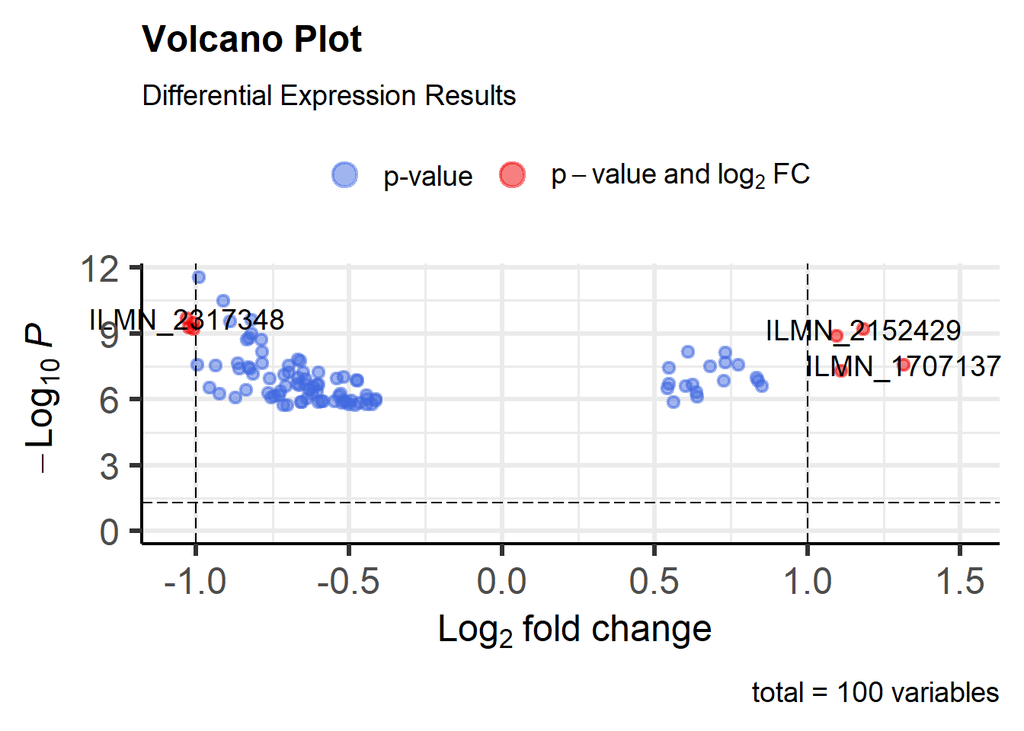

```r
# Volcano Plot
EnhancedVolcano(volcano_data,
                lab = volcano_data$rownames.results.,
                x = "logFC",
                y = "results.P.Value",
                pCutoff = 0.05,
                FCcutoff = 1.0,
                # Change axis limits
                xlim = c(-1.05, 1.5),     # X-axis: log2 fold change from -1.05 to +1.5
                ylim = c(0, 11.6),      # Y-axis: -log10(p-value) from 0 to 11.6
                title = "Volcano Plot",
                subtitle = 'Differential Expression Results')
```

### 1. D. Functional Enrichment Analysis

Once DEGs are identified, functional enrichment analysis can elucidate biological pathways and processes significantly associated with the list of altered genes. Tools like “clusterProfiler” facilitate pathway analysis, such as Gene Ontology (GO) and Kyoto Encyclopedia of Genes and Genomes (KEGG).

```r
# Install "clusterProfiler" and "BSgenome.Hsapiens.UCSC.hg38" packages
# BiocManager::install("clusterProfiler")
# BiocManager::install("org.Hs.egGO")
# BiocManager::install("topGO")
# BiocManager::install("Rgraphviz")

# Install gprofiler2 if not already installed
# if (!requireNamespace("gprofiler2", quietly = TRUE)) {
#   install.packages("gprofiler2")
# }


# Load libraries
library(clusterProfiler)
library(AnnotationDbi)
library(org.Hs.eg.db)
library(gprofiler2)
library(topGO)
library(Rgraphviz)
# Example: Illumina probe IDs (replace with your own list)
illumina_ids <- c(rownames(results))

# Convert Illumina IDs to Entrez Gene IDs for human (hsapiens)
# The 'target' parameter specifies the output namespace
# The 'organism' parameter specifies the species
conversion_result <- gconvert(
  query = illumina_ids,
  organism = "hsapiens",
  target = "ENTREZGENE_ACC",  # Entrez Gene ID
  filter_na = TRUE            # Remove rows with no match
)

# Display the conversion table
head(conversion_result, n = 2)
```

```
##   input_number        input target_number target  name
## 1            1 ILMN_2106902           1.1   1112 FOXN3
## 2            2 ILMN_1801703           2.1  10815 CPLX1
##                                          description
## 1 forkhead box N3 [Source:HGNC Symbol;Acc:HGNC:1928]
## 2     complexin 1 [Source:HGNC Symbol;Acc:HGNC:2309]
##                                      namespace
## 1 ILLUMINA_HUMANREF_8_V3,ILLUMINA_HUMANWG_6_V3
## 2 ILLUMINA_HUMANREF_8_V3,ILLUMINA_HUMANWG_6_V3
```

```
##
## groupGOTerms:    GOBPTerm, GOMFTerm, GOCCTerm environments built.
```

```
##
## Building most specific GOs .....
```

```
##  ( 386 GO terms found. )
```

```
##
## Build GO DAG topology ..........
```

```
##  ( 386 GO terms and 490 relations. )
```

```
##
## Annotating nodes ...............
```

```
##  ( 18662 genes annotated to the GO terms. )
```

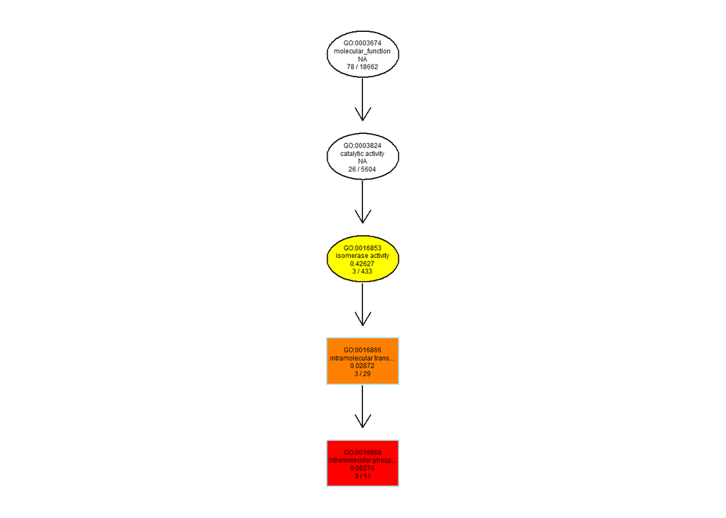

```
## $dag
## A graphNEL graph with directed edges
## Number of Nodes = 5
## Number of Edges = 4
##
## $complete.dag
## [1] "A graph with 5 nodes."
```

```r
# Performing GO analysis
go_results <- enrichGO(gene = conversion_result$name, OrgDb = org.Hs.eg.db,
                       keyType = "SYMBOL", pAdjustMethod = "BH")

plotGOgraph(go_results)
```

### 1. E. Visualization

Effective visualization aids in understanding the results of gene expression analysis. In addition to the volcano plot, heatmaps, and clustering dendrograms can illustrate expression patterns across samples.

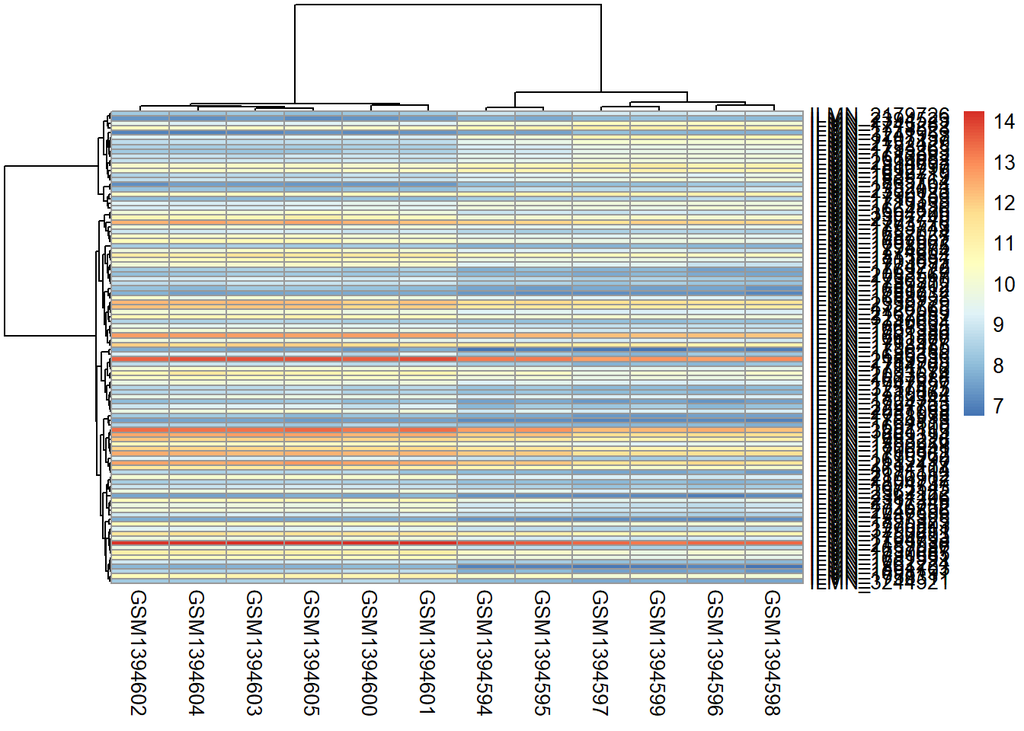

```r
# Load library
library(pheatmap)

# Heatmap Generation
heatmapData <- normalized_data[rownames(results[results$adj.P.Val < 0.05,]),]

pheatmap(heatmapData, clustering_distance_rows = "correlation",
         clustering_distance_cols = "correlation")
```

By integrating tools and techniques for data pre-processing, normalization, differential expression analysis, functional enrichment and visualization, researchers can derive meaningful biological insights from gene expression profiles. As bioinformatics continues to evolve, leveraging R and its extensive Bioconductor ecosystem will remain essential for unlocking the mysteries of gene regulation in health and disease.

## 2. Pre-processing Microarray Data with Affy and Oligo

This chapter focuses on the pre-processing of microarray data using two popular R packages: **affy** and **oligo**. By the end of this chapter, you will have a solid understanding of how to pre-process microarray data, enhancing the reliability and interpretability of your analyses

### 2. A. Overview of Microarray Data

Microarray experiments involve measuring the expression levels of thousands of genes across different samples. The raw output from these experiments typically consists of intensity values for each probe in the microarray. Different platforms and technologies often yield raw data in formats such as CEL files (for Affymetrix arrays) or TXT files (for Illumina arrays). Standard pre-processing steps help transform these raw data into normalized gene expression values that are ready for downstream analysis.

### 2. B. Pre-processing Workflow

A typical microarray data pre-processing workflow includes the following steps.

- **Importing raw data**
- **Quality assessment**
- **Background correction**
- **Normalization**
- **Summarization**
- **Filtering and transformation**

This chapter will delve into each of these steps, detailing how to implement them using **affy** and **oligo**.

### 2. C. Importing Raw Data

#### 2. C. I. Using Affy.

The **Affy** package is designed for processing Affymetrix micro-array data. The first step is to load the required libraries and import the CEL files:

```r
# Install "oligo" if not already installed
BiocManager::install("oligo")
BiocManager::install("illuminaio")
# Load necessary libraries
library(affy)
library(oligo)
# Set working directory to where CEL files are located
setwd("D:/Ajay Files/R Programming for Bioinformatics/Chapter 7/Microarrays")

# Read in the CEL files
rawData_affy <- ReadAffy()
rawData_affy
```

```
## AffyBatch object
## size of arrays=712x712 features (22 kb)
## cdf=ATH1-121501 (22810 affyids)
## number of samples=9
## number of genes=22810
## annotation=ath1121501
## notes=
```

#### 2. C. II. Using oligo

The **oligo** package is versatile and can handle almost any microarray data, including Illumina and Agilent platforms. For instance, to import Illumina data, you can use:

```r
# Load necessary libraries
library(oligo)
library(illuminaio)

# Read in the IDAT files for Illumina arrays
# rawData_Ill <- read.idat("D:/Ajay Files/R Programming for Bioinformatics/Chapter 7/IDAT example files")
```

Make sure to replace the path with the actual location of your data files.

### 2. D. Quality Assessment

Quality control is essential in any micro-array experiment. We can visualize the data using box plots which help identify any outliers:

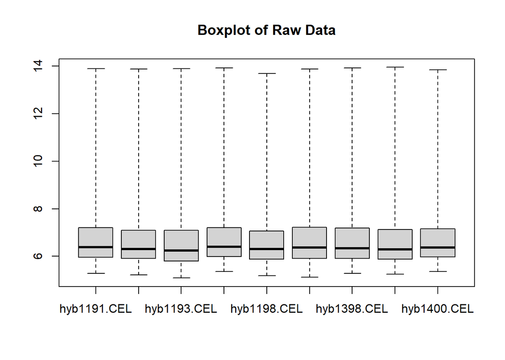

```r
# Create boxplots for quality assessment
boxplot(rawData_affy, main = "Boxplot of Raw Data")
```

#### 2. D. I. Affy Quality Metrics

For Affymetrix arrays, you can use the “affyqc()” function to generate quality metrics:

```r
# Generate quality metrics
# affyQCMetrics <- affyQC(rawData_affy) # affyQC() doesn't work!

# Alternative
# BiocManager::install("affyPLM")
library(affyPLM)
fit <- fitPLM(rawData_affy)
fit
```

```
## Probe level linear model (PLMset) object
## size of arrays=712x712
## cdf=ATH1-121501 (22810 probeset ids)
## number of samples=9
## number of probesets=22810
## number of chip level parameters for each probeset=9
## annotation=ath1121501
## PLMset settings
## Creating function: fitPLM
## Preprocessing
## Background Correction=TRUE Method= RMA.2
## Normalization=TRUE Method= quantile
##
## Model/Summarization
## $constraint.type
##           default
## "contr.treatment"
##
## $variable.type
##  default
## "factor"
##
## $model.param
## $model.param$trans.fn
## [1] "log2"
##
## $model.param$se.type
## [1] 4
##
## $model.param$psi.type
## [1] 0
##
## $model.param$psi.k
## [1] 1.345
##
## $model.param$max.its
## [1] 20
##
## $model.param$init.method
## [1] "ls"
##
## $model.param$weights.chip
## NULL
##
## $model.param$weights.probe
## NULL
##
##
##
## Output Settings
## $weights
## [1] TRUE
##
## $residuals
## [1] TRUE
##
## $varcov
## [1] "none"
##
## $resid.SE
## [1] TRUE
```

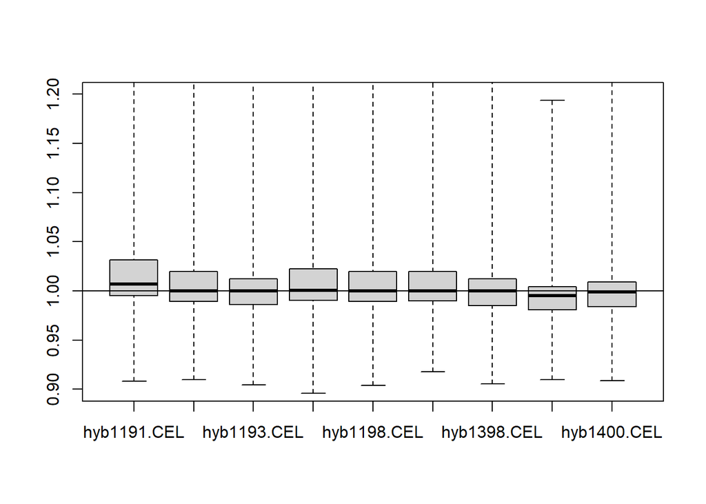

```r
NUSE(fit)
```

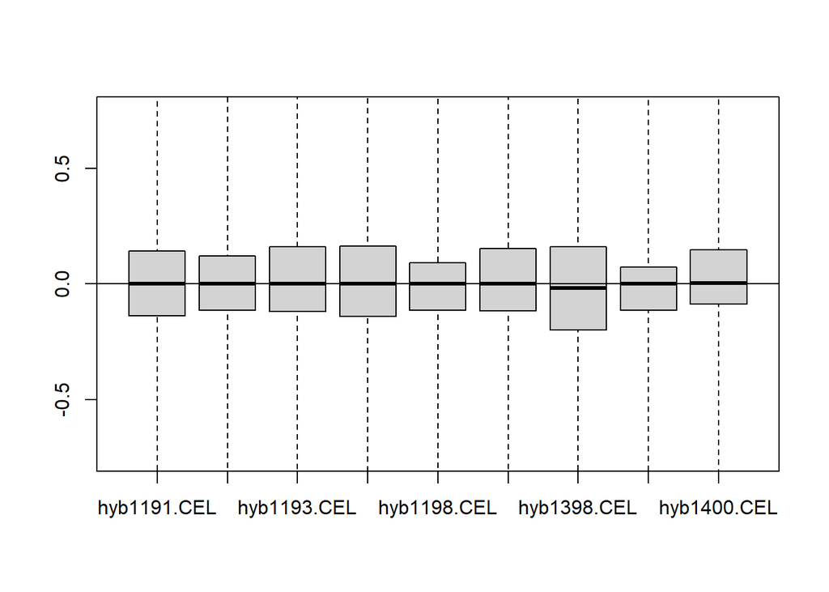

```r
RLE(fit)
```

#### 2. D. II. Oligo Quality Metrics

For Illumina and other arrays, the **oligo** package provides similar tools, but you may need to evaluate metrics specific to your platform.

### 2. E. Background Correction

Background correction is a technique to adjust for any inherent noise in the micro-array experiment. The **affy** package provides several algorithms for background correction.

#### 2. E. I. Perform background correction on Affymetrix micro-array

Run the MAS 5.0 algorithm, which performs background correction, normalization, and summarization

```r
bgCorrectedData_affy <- mas5(rawData_affy)
```

```
## background correction: mas
## PM/MM correction : mas
## expression values: mas
## background correcting...done.
## 22810 ids to be processed
## |                    |
## |####################|
```

```r
bgCorrectedData_affy # Expression set created
```

```
## ExpressionSet (storageMode: lockedEnvironment)
## assayData: 22810 features, 9 samples
##   element names: exprs, se.exprs
## protocolData
##   sampleNames: hyb1191.CEL hyb1192.CEL ... hyb1400.CEL (9 total)
##   varLabels: ScanDate
##   varMetadata: labelDescription
## phenoData
##   sampleNames: hyb1191.CEL hyb1192.CEL ... hyb1400.CEL (9 total)
##   varLabels: sample
##   varMetadata: labelDescription
## featureData: none
## experimentData: use 'experimentData(object)'
## Annotation: ath1121501
```

#### 2. E. II. Perform background correction on Illumina micro-array

In **oligo**, you can use the quantile normalization method to perform background correction:

```r
# Perform background correction and normalization
# bgCorrectedData_Ill <- normalize(rawData_Ill)
```

### 2. F. Normalization

Normalization is crucial for reducing systematic biases across arrays. The **affy** package offers various normalization methods like RMA (Robust Multi- array Average)

#### 2. F. I. Normalize the data using RMA

The rma function is available on oligo and affy packages so you have to specify which package to get the rma function from. The rma function converts affy batch data into an Expression set but you also have to specify you want to normalize the data. You can’t normalize an expression set (bgCorrectedData_affy) using rma, you have to use an affy batch data set(rawData_affy).

```r
normalizedData <- affy::rma(rawData_affy, normalize = TRUE)
```

```
## Background correcting
## Normalizing
## Calculating Expression
```

```r
normalizedData
```

```
## ExpressionSet (storageMode: lockedEnvironment)
## assayData: 22810 features, 9 samples
##   element names: exprs
## protocolData
##   sampleNames: hyb1191.CEL hyb1192.CEL ... hyb1400.CEL (9 total)
##   varLabels: ScanDate
##   varMetadata: labelDescription
## phenoData
##   sampleNames: hyb1191.CEL hyb1192.CEL ... hyb1400.CEL (9 total)
##   varLabels: sample
##   varMetadata: labelDescription
## featureData: none
## experimentData: use 'experimentData(object)'
## Annotation: ath1121501
```

With _oligo__, normalization is typically integrated into the data importing process. Ensure to follow the specific normalization method recommended by your array type.

### 2. G. Summarization

#### 2. G. I. Summarization - affy

Summarization transforms probe-level data to a gene-expression measure. In the **affy** package, we can achieve this through “rma()” or “mas5()” depending on your analysis needs:

```r
# Summarize the data to gene-level
summarizedData <- exprs(normalizedData)
head(summarizedData, n = 2)
```

```
##           hyb1191.CEL hyb1192.CEL hyb1193.CEL hyb1197.CEL hyb1198.CEL
## 244901_at    3.575130    4.626712    5.905113    3.205851    4.688164
## 244902_at    3.802281    4.250900    5.762482    3.647034    4.479414
##           hyb1199.CEL hyb1398.CEL hyb1399.CEL hyb1400.CEL
## 244901_at    5.841901    4.117778    4.691074    5.798797
## 244902_at    5.177922    3.408042    4.479414    5.665778
```

#### 2. G. II. Summarization - oligo

In **oligo**, summarization is handled internally during normalization:

```r
# Extract summarized data for further analysis
# geneExpressionData <- exprs(normalizedData)
```

### 2. H. Filtering and Transformation

Once you have a summarized expression matrix, filtering lowly-expressed genes can enhance the quality of your downstream analysis. It often involves setting a threshold for expression levels:

```r
# Dimensions of summarized data prior to filtering
dim(summarizedData)
```

```
## [1] 22810     9
```

```r
# Filtering
threshold = 3
filteredData <- summarizedData[rowMeans(summarizedData) > threshold,]
head(filteredData, n = 2)
```

```
##           hyb1191.CEL hyb1192.CEL hyb1193.CEL hyb1197.CEL hyb1198.CEL
## 244901_at    3.575130    4.626712    5.905113    3.205851    4.688164
## 244902_at    3.802281    4.250900    5.762482    3.647034    4.479414
##           hyb1199.CEL hyb1398.CEL hyb1399.CEL hyb1400.CEL
## 244901_at    5.841901    4.117778    4.691074    5.798797
## 244902_at    5.177922    3.408042    4.479414    5.665778
```

```r
# Dimensions of summarized data after filtering
dim(filteredData)
```

```
## [1] 18762     9
```

It’s essential to choose a threshold based on biological relevance and experimental design.

We explored the systematic process of pre-processing microarray data using **affy** and **oligo** in R. We walked through the steps of importing data, performing quality assessment, background correction, normalization, summarization and filtering of gene expression data. Each of these steps is essential to ensure that the data analyzed is of high quality and can yield meaningful biological insights.

## 3. Differential Expression Analysis with limma

The objective of this analysis is to identify genes whose expression levels significantly differ between defined experimental groups, aiding in the understanding of biological processes, disease mechanisms, and potential therapeutic targets.

In the realm of bioinformatics, one of the most widely used tools for differential expression analysis is the “limma” packages, which stands for “linear models for microarray data”. Originally developed for microarray data, limma has been successfully adapted for RNA-seq data, particularly through the use of voom transformation. This chapter covers the basic concepts and step-by-step procedures for conducting differential expression analysis using limma in R, providing practical examples and insights for researchers in the field.

### 3. A. Overview of the limma Package

The limma package is implemented in R, offering a suite of functions for the analysis of gene expression data. It employs linear modelling to assess differential expression and is particularly noted for its robust statistical framework, allowing for the inclusion of complex designs and the incorporation of multiple testing corrections. The core functionalities of limma can be best summarized as follows:

- **Modelling**: Fit linear models to expression data
- **Hypothesis Testing**: Test for differential expression using empirical Bayes methods.
- **Multiple Testing Adjustment**: Control the false discovery rate (FDR) and provide adjusted p-values.

### 3. B. Installation and Loading of limma

To get started with limma, you’ll first need to install the package from Bioconductor, as it is not available on CRAN. The installation process can be accomplished via the following commands in R:

```r
# Install BiocManager if you haven't already.
# install.packages("BiocManager")

# Install limma
# BiocManager::install("limma")

# Once installed, load the package into your R session:
library(limma)
```

### 3. C. Data Preparation

The initial step in any differential expression analysis is data preparation. For this example, we will consider a hypothetical RNA-seq dataset. The dataset might be structured with genes as rows and samples as columns, often stored in a data frame or matrix format. Here’s a basic structure of how your data might look:

```r
# Random seed for reproducibility
set.seed(123)

# Create 100 rows X 10 columns count matrix with negative binomial distribution
gene_counts <- matrix(rnbinom(n = 1000, mu = 10, size = 1),
                      nrow = 100, ncol = 10)
rownames(gene_counts) <- paste0("Gene_", 1:100)
colnames(gene_counts) <- paste0("Sample_", 1:10)

head(gene_counts)
```

```
##        Sample_1 Sample_2 Sample_3 Sample_4 Sample_5 Sample_6 Sample_7 Sample_8
## Gene_1        3       16        0       21        8       45       11        7
## Gene_2       22       10       18        7        0        2       24        4
## Gene_3       10       18       18       13        2        9       11        5
## Gene_4        2       26        7        1        1        9        2        3
## Gene_5       10        8        7        3        8        0       11        1
## Gene_6       18        1        3       17        0        6       12       36
##        Sample_9 Sample_10
## Gene_1        0        10
## Gene_2        7         4
## Gene_3        6        15
## Gene_4       20         5
## Gene_5        0        10
## Gene_6       12        24
```

```r
# Creating a data frame to hold sample information
sample_info <- data.frame(Group = rep(c("Control", "Treatment"), each = 5))
sample_info
```

```
##        Group
## 1    Control
## 2    Control
## 3    Control
## 4    Control
## 5    Control
## 6  Treatment
## 7  Treatment
## 8  Treatment
## 9  Treatment
## 10 Treatment
```

### 3. D. Normalization and Transformations

Before fitting models, it’s critical to normalize the count data to account for differences in sequencing depth and composition. For RNA-seq data, the voom function is used:

```r
# Load edgeR library
library(edgeR) # This is often  required for voom

# Creating a DGEList object for normalization
dge <- DGEList(counts = gene_counts)
dge
```

```
## An object of class "DGEList"
## $counts
##        Sample_1 Sample_2 Sample_3 Sample_4 Sample_5 Sample_6 Sample_7 Sample_8
## Gene_1        3       16        0       21        8       45       11        7
## Gene_2       22       10       18        7        0        2       24        4
## Gene_3       10       18       18       13        2        9       11        5
## Gene_4        2       26        7        1        1        9        2        3
## Gene_5       10        8        7        3        8        0       11        1
##        Sample_9 Sample_10
## Gene_1        0        10
## Gene_2        7         4
## Gene_3        6        15
## Gene_4       20         5
## Gene_5        0        10
## 95 more rows ...
##
## $samples
##           group lib.size norm.factors
## Sample_1      1      840            1
## Sample_2      1     1092            1
## Sample_3      1      887            1
## Sample_4      1      955            1
## Sample_5      1      991            1
## Sample_6      1     1072            1
## Sample_7      1     1037            1
## Sample_8      1      843            1
## Sample_9      1      995            1
## Sample_10     1     1045            1
```

```r
# Applying voom transformation
v <- voom(dge, design = model.matrix(~ Group, data = sample_info))
v
```

```
## An object of class "EList"
## $targets
##           group lib.size norm.factors
## Sample_1      1      840            1
## Sample_2      1     1092            1
## Sample_3      1      887            1
## Sample_4      1      955            1
## Sample_5      1      991            1
## Sample_6      1     1072            1
## Sample_7      1     1037            1
## Sample_8      1      843            1
## Sample_9      1      995            1
## Sample_10     1     1045            1
##
## $E
##        Sample_1 Sample_2  Sample_3 Sample_4  Sample_5  Sample_6 Sample_7
## Gene_1 12.02296 13.88189  9.137153 14.45697 13.064835 15.371929 13.43554
## Gene_2 14.70746 13.22981 14.346606 12.93759  8.977372 11.186062 14.52669
## Gene_3 13.60792 14.04694 14.346606 13.78559 11.299300 13.112062 13.43554
## Gene_4 11.53753 14.56541 13.044043 10.61566 10.562335 13.112062 11.23391
## Gene_5 13.60792 12.92495 13.044043 11.83806 13.064835  8.864134 13.43554
##        Sample_8  Sample_9 Sample_10
## Gene_1 13.11736  8.971567  13.29322
## Gene_2 12.38039 12.878457  12.07083
## Gene_3 12.66990 12.672006  13.85510
## Gene_4 12.01782 14.329119  12.36033
## Gene_5 10.79543  8.971567  13.29322
## 95 more rows ...
##
## $weights
##           [,1]      [,2]      [,3]      [,4]      [,5]      [,6]      [,7]
## [1,] 0.3275535 0.3720539 0.3285900 0.3340662 0.3420149 0.4546550 0.4403461
## [2,] 0.3597365 0.4631471 0.3786689 0.4063631 0.4214857 0.3891097 0.3771804
## [3,] 0.5227042 0.6580188 0.5476098 0.5838576 0.6032574 0.5491354 0.5337384
## [4,] 0.3221853 0.3257290 0.3232343 0.3245702 0.3249950 0.3896695 0.3777073
## [5,] 0.3732737 0.4797383 0.3928711 0.4223207 0.4381312 0.3194821 0.3194632
##           [,8]      [,9]     [,10]
## [1,] 0.3604971 0.4226405 0.4436769
## [2,] 0.3304533 0.3626953 0.3798849
## [3,] 0.4441045 0.5152339 0.5372577
```

[output cut: 10 more lines]

```
## 5            1              0
## 6            1              1
## 7            1              1
## 8            1              1
## 9            1              1
## 10           1              1
## attr(,"assign")
## [1] 0 1
## attr(,"contrasts")
## attr(,"contrasts")$Group
## [1] "contr.treatment"
##
##
## $span
## [1] 0.8555904
```

### 3. E. Linear Model Fitting

Once the data is normalized, we can fit a linear model to the transformed data. The design matrix describes the structure of the experimental groups, which will be used in the modelling process.

```r
# Fit the linear model
fit <- lmFit(v, design = model.matrix(~ Group, data = sample_info))
fit
```

```
## An object of class "MArrayLM"
## $coefficients
##        (Intercept) GroupTreatment
## Gene_1    12.55857      0.3189027
## Gene_2    12.75843     -0.1562874
## Gene_3    13.40364     -0.2339117
## Gene_4    12.06636      0.5487928
## Gene_5    12.87937     -1.8073852
## 95 more rows ...
##
## $stdev.unscaled
##        (Intercept) GroupTreatment
## Gene_1   0.7660017      1.0286171
## Gene_2   0.7019659      1.0180542
## Gene_3   0.5856624      0.8547965
## Gene_4   0.7855011      1.0770378
## Gene_5   0.6890270      1.0491970
## 95 more rows ...
##
## $sigma
## [1] 1.3872197 1.1614549 0.7131001 0.8571773 0.9377326
## 95 more elements ...
##
## $df.residual
## [1] 8 8 8 8 8
## 95 more elements ...
##
## $cov.coefficients
##                (Intercept) GroupTreatment
## (Intercept)            0.2           -0.2
## GroupTreatment        -0.2            0.4
##
## $pivot
## [1] 1 2
##
## $rank
## [1] 2
##
## $Amean
##   Gene_1   Gene_2   Gene_3   Gene_4   Gene_5
```

[output cut: 8 more lines]

```
## 1            1              0
## 2            1              0
## 3            1              0
## 4            1              0
## 5            1              0
## 6            1              1
## 7            1              1
## 8            1              1
## 9            1              1
## 10           1              1
## attr(,"assign")
## [1] 0 1
## attr(,"contrasts")
## attr(,"contrasts")$Group
## [1] "contr.treatment"
```

### 3. F. Empirical Bayes Moderation

To improve the estimation of the variance and its reliability, we apply empirical Bayes moderation:

```r
fit <- eBayes(fit)
fit
```

```
## An object of class "MArrayLM"
## $coefficients
##        (Intercept) GroupTreatment
## Gene_1    12.55857      0.3189027
## Gene_2    12.75843     -0.1562874
## Gene_3    13.40364     -0.2339117
## Gene_4    12.06636      0.5487928
## Gene_5    12.87937     -1.8073852
## 95 more rows ...
##
## $stdev.unscaled
##        (Intercept) GroupTreatment
## Gene_1   0.7660017      1.0286171
## Gene_2   0.7019659      1.0180542
## Gene_3   0.5856624      0.8547965
## Gene_4   0.7855011      1.0770378
## Gene_5   0.6890270      1.0491970
## 95 more rows ...
##
## $sigma
## [1] 1.3872197 1.1614549 0.7131001 0.8571773 0.9377326
## 95 more elements ...
##
## $df.residual
## [1] 8 8 8 8 8
## 95 more elements ...
##
## $cov.coefficients
##                (Intercept) GroupTreatment
## (Intercept)            0.2           -0.2
## GroupTreatment        -0.2            0.4
##
## $pivot
## [1] 1 2
##
## $rank
## [1] 2
##
## $Amean
##   Gene_1   Gene_2   Gene_3   Gene_4   Gene_5
```

[output cut: 64 more lines]

```
##        (Intercept) GroupTreatment
## Gene_1   110.12448      -5.136050
## Gene_2   137.58030      -5.165286
## Gene_3   223.97309      -5.273090
## Gene_4    95.73624      -5.057478
## Gene_5   146.04543      -4.254201
## 95 more rows ...
##
## $F
## [1] 248.7147 294.0641 463.9543 222.7880 276.4131
## 95 more elements ...
##
## $F.p.value
## [1] 9.651286e-109 1.947936e-128 3.215286e-202  1.755420e-97 9.021972e-121
## 95 more elements ...
```

### 3. G. Identifying Differentially Expressed Genes

After fitting the model and applying empirical Bayes methods, we can create a table of differentially expressed genes (DEGs) using the “topTable” function. This function allows for the extraction of genes based on adjusted p-values:

```r
result <- topTable(fit, coef = 2, adjust.method = "BH", number = Inf)
head(result)
```

```
##             logFC  AveExpr         t     P.Value adj.P.Val         B
## Gene_63 -2.878966 12.85264 -2.902473 0.003804030 0.2058103 -2.204561
## Gene_39 -2.858295 12.55124 -2.877416 0.004116207 0.2058103 -2.257937
## Gene_18  2.512419 13.00063  2.536512 0.011385331 0.2886010 -2.917958
## Gene_51 -2.510033 12.79425 -2.531622 0.011544041 0.2886010 -2.927427
## Gene_61  2.617218 11.70091  2.429215 0.015350771 0.3070154 -3.154360
## Gene_64  2.192721 13.82495  2.361591 0.018435447 0.3072575 -3.202029
```

In this case, “coef = 2” indicates that we want to compare the Treatment group against the control group. The results can be filtered based on significance levels, typically a threshold of FDR < 0.05 is used to declare differential expression

### 3. H. Visualization

Visualization is crucial in understanding the results of differential expression analyses. Common techniques include volcano plots and heatmaps.

#### 3. H. I. Visualization - volcano plot

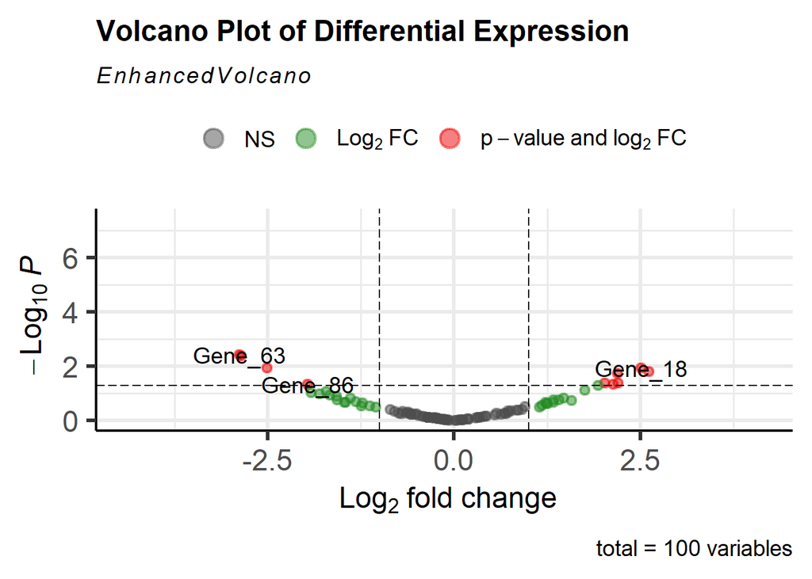

```r
# Install package
# BiocManager::install("EnhancedVolcano")

# Load Library
library(EnhancedVolcano)

# Volcano Plot
EnhancedVolcano(result,
                lab = rownames(result), x = "logFC",
                y = "P.Value", pCutoff = 0.05,
                title = "Volcano Plot of Differential Expression")
```

#### 3. H. II. Visualization - Heat Map

Heat maps can be created to visualize the expression patterns of DEGs across samples:

```r
# load Library
library(pheatmap)

# Select top DEGs for heatmap
top_genes <- head(row.names(result[result$P.Value < 0.05,]), 20)
top_genes
```

```
##  [1] "Gene_63" "Gene_39" "Gene_18" "Gene_51" "Gene_61" "Gene_64" "Gene_92"
##  [8] "Gene_99" "Gene_86" "Gene_56"
```

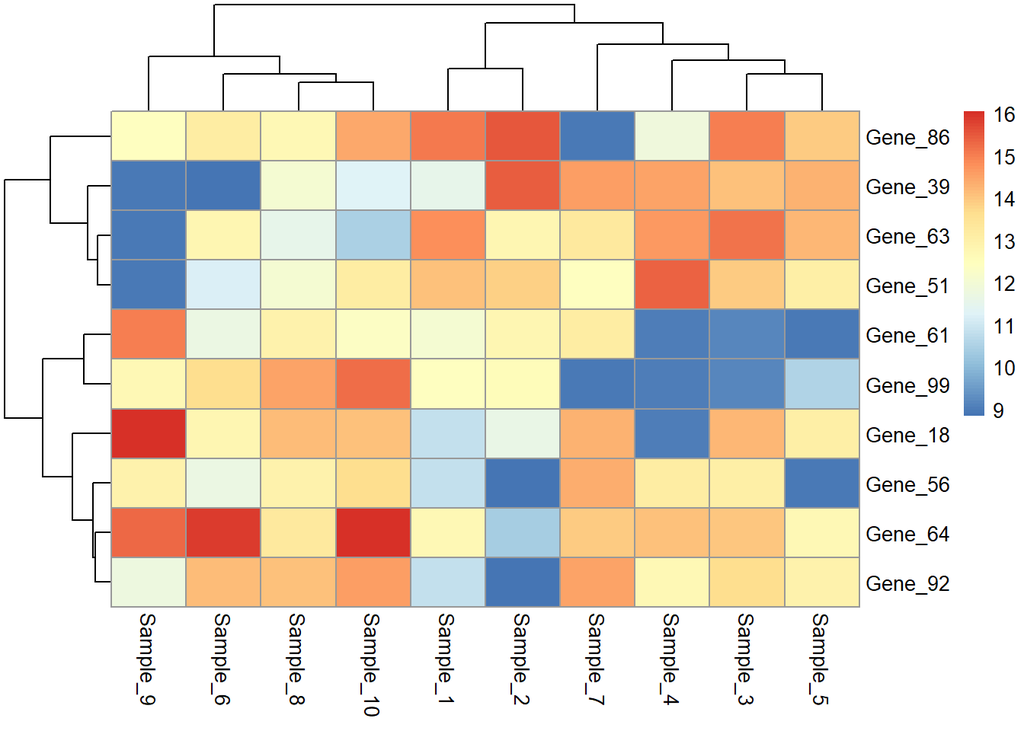

```r
# Heatmap
pheatmap(v$E[top_genes,], clustering_distance_rows = "correlation",
         clustering_distance_cols = "euclidean")
```

This chapter introduced the fundamental concepts and procedures for conducting differential expression analysis using the limma package in R. Through a systematic approach encompassing data preparation, normalization, model fitting, hypothesis testing and visulization, researchers can leverage limma to glean biological insights from gene expression data.

```r
Sys.Date()
```

```
## [1] "2026-01-18"
```